GeoStat Lab · M10 · Previsione e progetto statistico

M10_N12 · Futura

# Un grafico e una diagnostica utili alla domanda

5 blocchi R eseguiti3 grafici0 errori · 0 avvisiOffline · MathML

Codice, output e figure dello stesso svolgimento. Ogni notebook riparte dai dati locali ed è autonomo rispetto agli altri.

# La domanda

Quali grafici distinguono adattamento e previsione?

## Obiettivi

- Disegnare osservato contro previsto nel test.
- Esaminare i residui nel train.
- Collegare gli assi alla quantità misurata.

**Prima di iniziare.** Sono richiesti vettori, tabelle e funzioni R di base. I blocchi vanno eseguiti in ordine. Il notebook è autonomo rispetto agli altri.

**Dati e unità.** 160 fossili sintetici del corso. Diametri e spessore sono espressi in micrometri. Il diametro interno deriva dal totale meno due volte lo spessore, entro l’arrotondamento del CSV. Il test contiene ogni quinta riga: 32 individui, separati dai 128 usati per stimare. È un protocollo didattico su dati già noti, non una validazione prospettica.

## Preparazione

Aprire il progetto autonomo di Futura o quello generale del corso. I calcoli usano R base e stats. Gli output del notebook vanno in `Risultati/M10_N12/`; i CSV originali restano invariati.

Codice R · preparazione

```r
# Trova la cartella M10 dal progetto autonomo o dal progetto generale.
.gs_cerca <- normalizePath(getwd(),winslash="/",mustWork=TRUE)
repeat {
  .gs_candidati <- c(.gs_cerca,
    file.path(.gs_cerca,"M10_Futura"),
    file.path(.gs_cerca,"03_Notebook_svolti","M10_Futura"),
    file.path(.gs_cerca,"M10","03_Notebook_svolti","M10_Futura"))
  .gs_ok <- file.exists(file.path(.gs_candidati,"M10_N01.Rmd")) &
    file.exists(file.path(.gs_candidati,"R","funzioni_notebook.R"))
  if(any(.gs_ok)) { .gs_modulo <- .gs_candidati[which(.gs_ok)[1L]]; break }
  .gs_padre <- dirname(.gs_cerca)
  if(.gs_padre==.gs_cerca) stop("Aprire il progetto M10_Futura o quello generale dei notebook.")
  .gs_cerca <- .gs_padre
}
source(file.path(.gs_modulo,"R","funzioni_notebook.R"),local=TRUE)
.gs_funzioni <- .gs_prepara_notebook(.gs_modulo,"M10_N12")
carica_dati <- .gs_funzioni$carica_dati
percorso_risultati <- .gs_funzioni$percorso_risultati
options(width=88,digits=6)
if(requireNamespace("knitr",quietly=TRUE)) {
  knitr::opts_chunk$set(echo=TRUE,error=FALSE,warning=TRUE,message=TRUE,
    fig.width=8,fig.height=5,dpi=150,fig.align="center")
}
set.seed(10012)
```

## 1. La bisettrice rappresenta una previsione esatta

Ogni punto del test confronta lo stesso individuo previsto e osservato. Assi con uguale scala permettono di leggere la distanza dalla bisettrice.

Codice R · passo_01

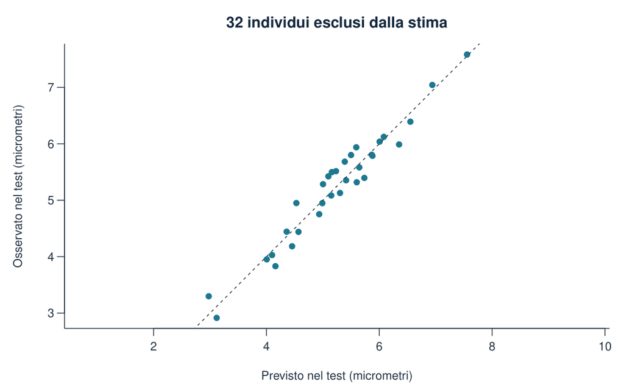

Figura 1 · Output del blocco `passo_01`. PDF vettoriale.

```r
f <- carica_dati("fossili_simulati.csv"); s <- prepara_fossili(f)
tr <- s$train; te <- s$test
mod <- lm(diametro_int_um~diametro_tot_um,data=tr)
prev <- as.numeric(predict(mod,newdata=te))
stile_grafico()
lim <- range(prev,te$diametro_int_um)
plot(prev,te$diametro_int_um,pch=19,col=palette_geo[1],xlim=lim,ylim=lim,asp=1,
  xlab="Previsto nel test (micrometri)",ylab="Osservato nel test (micrometri)",
  main="32 individui esclusi dalla stima")
abline(0,1,lty=2)
```

**Lettura del risultato.** La vicinanza alla bisettrice descrive la prestazione sui casi esclusi. Il grafico non mostra di per sé l’incertezza delle previsioni.

## 2. I residui servono alla diagnosi del train

Una struttura dei residui rispetto ai valori stimati può suggerire un andamento medio incompleto o una variabilità non costante.

Codice R · passo_02

```r
stile_grafico()
plot(fitted(mod),residuals(mod),pch=19,col=palette_geo[2],
  xlab="Stimato nel train (micrometri)",ylab="Residuo nel train (micrometri)",
  main="Diagnostica della regressione")
abline(h=0,lty=2)
data.frame(n_train=nobs(mod),sd_residua=sigma(mod),df_residui=df.residual(mod))
```

Output eseguito

```
  n_train sd_residua df_residui
1     128   0.266977        126
```

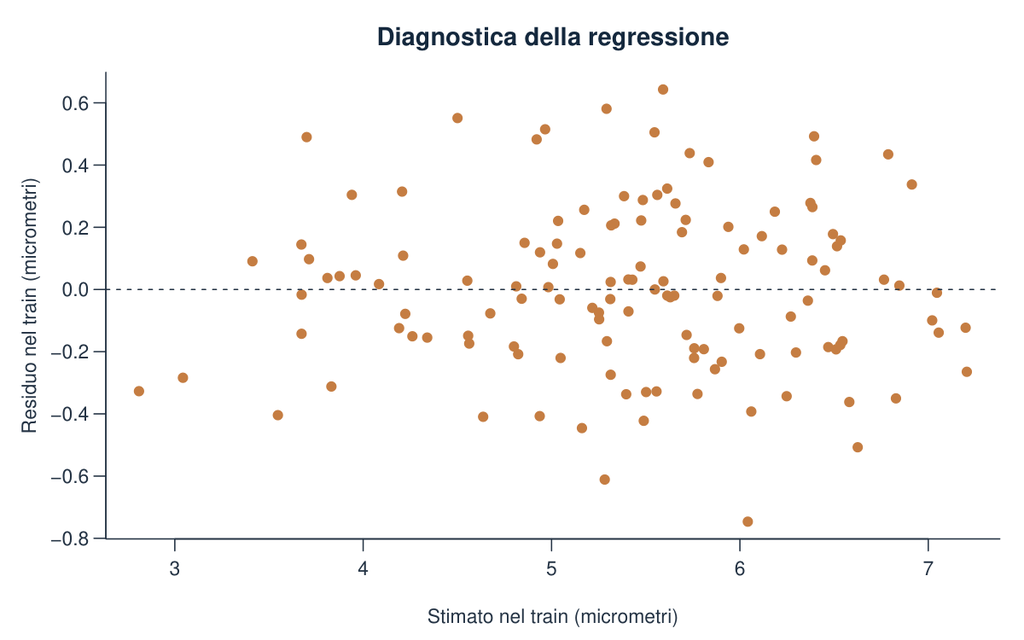

Figura 2 · Output del blocco `passo_02`. PDF vettoriale.

**Lettura del risultato.** Questi residui appartengono all’insieme che ha determinato i coefficienti. Non vanno usati al posto degli errori del test.

## 3. Il contesto del gruppo aiuta a leggere

I morfotipi sono metadati della simulazione. Li usiamo qui per descrivere gli errori, senza cambiare il modello già valutato.

Codice R · passo_03

```r
errori <- data.frame(id=te$id,morfotipo=te$morfotipo,errore=te$diametro_int_um-prev)
aggregate(errore~morfotipo,data=errori,FUN=mean)
aggregate(abs(errore)~morfotipo,data=errori,FUN=mean)
write.csv(errori,percorso_risultati("errori_per_individuo.csv"),row.names=FALSE)
```

Output eseguito

```
  morfotipo     errore
1   Rounded  0.1139852
2     Spiky -0.0965569
  morfotipo abs(errore)
1   Rounded    0.225893
2     Spiky    0.157887
```

**Lettura del risultato.** La descrizione per gruppo può orientare una successiva indagine. Un modello modificato dopo questo esame richiederebbe una nuova valutazione.

## Variante svolta

**Il QQ plot dei residui.** Esplorare la forma degli scarti del train.

Codice R · variante

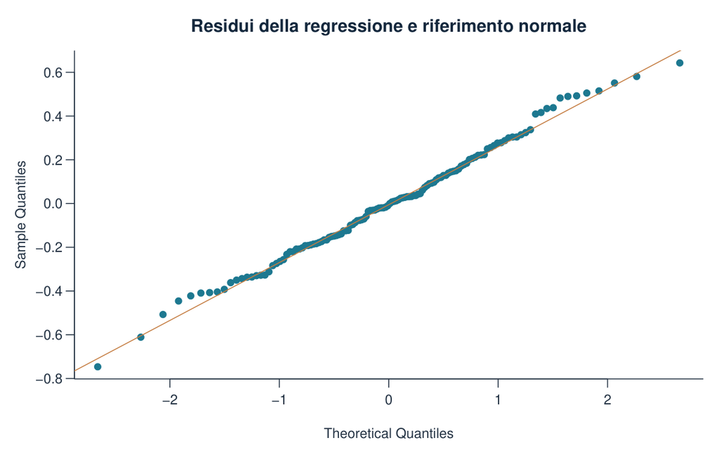

Figura 3 · Output del blocco `variante`. PDF vettoriale.

```r
stile_grafico()
qqnorm(residuals(mod),pch=19,col=palette_geo[1],main="Residui della regressione e riferimento normale")
qqline(residuals(mod),col=palette_geo[2])
```

La forma della distribuzione ha rilievo per gli intervalli del modello. La previsione puntuale e il suo errore restano oggetti distinti.

## Errore da riconoscere

Sovrapporre residui di adattamento ed errori di previsione in un solo grafico senza identificare gli insiemi.

## Risposta alla domanda

Osservato contro previsto documenta il test. Residui contro stimato documenta l’adattamento. Le etichette chiariscono quale informazione sostiene ciascuna conclusione.

## Riferimento nel corso

Questo svolgimento sviluppa il laboratorio `M10_N12` di [GeoStat Lab M10](https://marzione00.github.io/Lab_Geo/#indice). Il [codice originale del laboratorio](https://github.com/marzione00/Lab_Geo/blob/649f7cc577b96bd1044d81e78a2f530813e4f96b/materiali/laboratori/M10/M10_N12.R) è conservato anche in `R/Originali_corso`. Gli ampliamenti e le varianti sono identificati nella mappa allegata.

Documentazione dei metodi: [R stats, arima](https://stat.ethz.ch/R-manual/R-devel/library/stats/html/arima.html), [predict.Arima](https://stat.ethz.ch/R-manual/R-devel/library/stats/html/predict.arima.html), [Box.test](https://stat.ethz.ch/R-manual/R-devel/library/stats/html/box.test.html) e [p.adjust](https://stat.ethz.ch/R-manual/R-devel/library/stats/html/p.adjust.html).